# CITS4009 - Project 2

Joo Kai Tay (22489437)

2023-09-25

```css
img {
  display: block;
  margin-bottom: 0 !important;
}
```

# Introduction

The 2023 Global YouTube Statistic dataset can be accessed from Kaggle from the link below: https://www.kaggle.com/datasets/nelgiriyewithana/global-youtube-statistics-2023

This dataset contains various information about the top YouTube channels on the platform with the most subscribers. The data set contains information about their subscriber counts, video views, earnings and demographics.

The modelling process explored to predict high/low earnings is documented below in terms of code and comments.

# Data loading, and set up

Load the necessary libraries for data preparation, classification and clustering.

```r
library(ggplot2)
library(gridExtra)
library(dplyr)
library(knitr)
library(tidyverse)
library(ggrepel)
library(vtreat)
library(corrplot)
library(tidyr)
library(psych)
library(GGally)
library(stringr)
library(reshape2)
library(caret)
library(ROCR)
library(MASS)
library(FactoMineR)
library(tidymodels)
library(glmnet)
library(parsnip)
library(yardstick)
library(rpart)
library(rpart.plot)
library(fpc)
```

Read the YouTube dataset.

```r
path <- './data/youtube_UTF_8.csv'
youtube <- read.csv(path)
```

# Data Preparation

## Functions

This section contains all function used in the data preparation phase for this modelling exercise.

This function plots a correlation matrix for each numerical value in a given a dataframe. In addition to the color gradient, The function will display any correlation above 0.6 on the matrix to highlight to the user where the highly correlated values are in this dataset.

```r
# This function plots a correlation matrix for each numerical value in a given a dataframe
# @param df dataframe to plot
plot_corr <- function(df) {
  youtube_numeric <- df[, sapply(df, is.numeric) | sapply(df, is.integer)]

  correlation_matrix <- cor(youtube_numeric, use = "complete.obs")
  correlation_data <- melt(correlation_matrix)
  diag(correlation_matrix) <- NA

  format_label <- function(x) {
    ifelse(is.na(x), "", ifelse(abs(x) >= 0.6,sprintf("%.1f", x), ""))
  }

  custom_color_gradient <- c('forestgreen', 'lightblue', 'darkblue')

  heatmap_plot <- ggplot(correlation_data, aes(Var1, Var2, fill = value)) +
    geom_tile() +
    geom_text(aes(label = format_label(value)), vjust = 0.5, hjust=0.5, size = 2, color='white') +
    scale_fill_gradientn(colors = custom_color_gradient, values = scales::rescale(c(-1, 0, 1)), guide = "legend") +
      labs(
      title = "Correlation Matrix",
      x = NULL,
      y = NULL
    ) +
    theme_minimal() +
    theme(
      axis.text.x = element_text(angle = 45, hjust = 1),
      panel.grid.major = element_blank(),
      panel.grid.minor = element_blank(),
      plot.title = element_text(hjust = 0.5))


  print(heatmap_plot)
}
```

This function plots a histogram for each numerical value in a given dataframe. The function also allows us to select what type of variables we want to see which is very useful when exploring different feature combinations and attribute scaling methods.

```r
# This function plots a histogram for each numerical value in a given dataframe
# @param df dataframe to plot
# @param ncols number of columns in output plot
# @param var.type which selection of variables to plot
plot_hist <- function(df, ncols, var.type){

  numeric_cols <- sapply(df, is.numeric)
  if(var.type == "log"){
    total_numeric_cols <- sum(sapply(df, is.numeric) & grepl("\\.log$", names(df)))
    nrows <- ceiling(total_numeric_cols/ncols)
    par(mfrow=c(nrows,ncols), mar=c(2, 2, 1, 1))
  } else if(var.type == "default") {
    total_numeric_cols <- sum(numeric_cols)
    nrows <- ceiling(total_numeric_cols/ncols)
    par(mfrow=c(nrows,ncols), mar=c(2, 2, 1, 1))
  } else if(var.type == "minmax") {
    total_numeric_cols <- sum(sapply(df, is.numeric) & grepl("\\.minmax$", names(df)))
    nrows <- ceiling(total_numeric_cols/ncols)
    par(mfrow=c(nrows,ncols), mar=c(2, 2, 1, 1))
    par(mfrow=c(nrows,ncols), mar=c(2, 2, 1, 1))
  } else if(var.type == "norm") {
    total_numeric_cols <- sum(sapply(df, is.numeric) & grepl("\\.norm$", names(df)))
    nrows <- ceiling(total_numeric_cols/ncols)
    par(mfrow=c(nrows,ncols), mar=c(2, 2, 1, 1))
  }


  for(colname in names(df)[numeric_cols]) {
    if(var.type == "log" & grepl("\\.log$", colname)) {
      hist(df[[colname]], main=colname, xlab=NULL, col="lightblue", border="black", breaks=50)
    } else if(var.type == "default") {
      hist(df[[colname]], main=colname, xlab=NULL, col="lightblue", border="black", breaks=50)
    } else if (var.type == "minmax" & grepl("\\.minmax$", colname)) {
      hist(df[[colname]], main=colname, xlab=NULL, col="lightblue", border="black", breaks=50)
    } else if(var.type == "norm" & grepl("\\.norm$", colname)) {
      hist(df[[colname]], main=colname, xlab=NULL, col="lightblue", border="black", breaks=50)
    }
  }

  # Reset the plotting parameters to default
  par(mfrow=c(1, 1), mar=c(5, 4, 4, 2) + 0.1)
}
```

This function plots the histogram of an given variable and also shows the location of the mean and median.

```r
plot_individual_hist <- function(df, feature, title1, plot.mean) {
  mean_val <- mean(df[,feature], na.rm = TRUE)
  median_val <- median(df[,feature], na.rm = TRUE)

  p <- ggplot(df, aes(x = df[,feature])) +
  geom_histogram(fill = "lightgreen", alpha = 0.7, color="black") +
  labs(title=title1) +
  xlab(feature) +
  ylab("Frequency") +
  theme_minimal()

  if(plot.mean) {
    p <- p +
      geom_vline(aes(xintercept = mean_val), color = "red", linetype = "dashed", size = 1) +
      geom_vline(aes(xintercept = median_val), color = "blue", linetype = "dashed", size = 1) +
      annotate("text", x = mean_val, y = Inf, label = sprintf("Mean = %.2f", mean_val), vjust = 3, hjust = 3, color = "red", size = 3.5) +
      annotate("text", x = median_val, y = Inf, label = sprintf("Median = %.2f", median_val), vjust = 5, hjust = 3, color = "blue", size = 3.5)
  }

  return(p)
}
```

This function performs feature transformation on a given dataframe. We have the option to choose between log transformation, min-max scaling and z-normalization.

```r
# This function transforms the data
# @param df the dataframe to transform
# @param features the features to transform
# @param trans the type of transform to apply
transform_cols <- function(df, features, trans) {
  if(trans == "log"){
    # Apply log transform
    df <- df %>%
      mutate(across(all_of(features), ~log(. + 1e-6), .names = "{col}.log"))
  } else if (trans == "minmax") {
    # Applying min-max scaling
    df <- df %>%
      mutate(across(all_of(features), minmax_scale, .names = "{col}.minmax"))
  } else if (trans == "norm") {
    # Applying z-normalization
    df <- df %>%
      mutate(across(all_of(features), ~as.vector(scale(.)), .names = "{col}.norm"))
  }

  return(df)
}
```

## Inspecting the data

```r
str(youtube)
```

- 4 Integer Variables: Integers represent whole numbers without decimal points
- 7 Character Variables: Characters represent text or strings of characters
- 17 Numeric Variables: Represent real numbers, including integers & numbers with decimal points

## Data Correlation Matrix

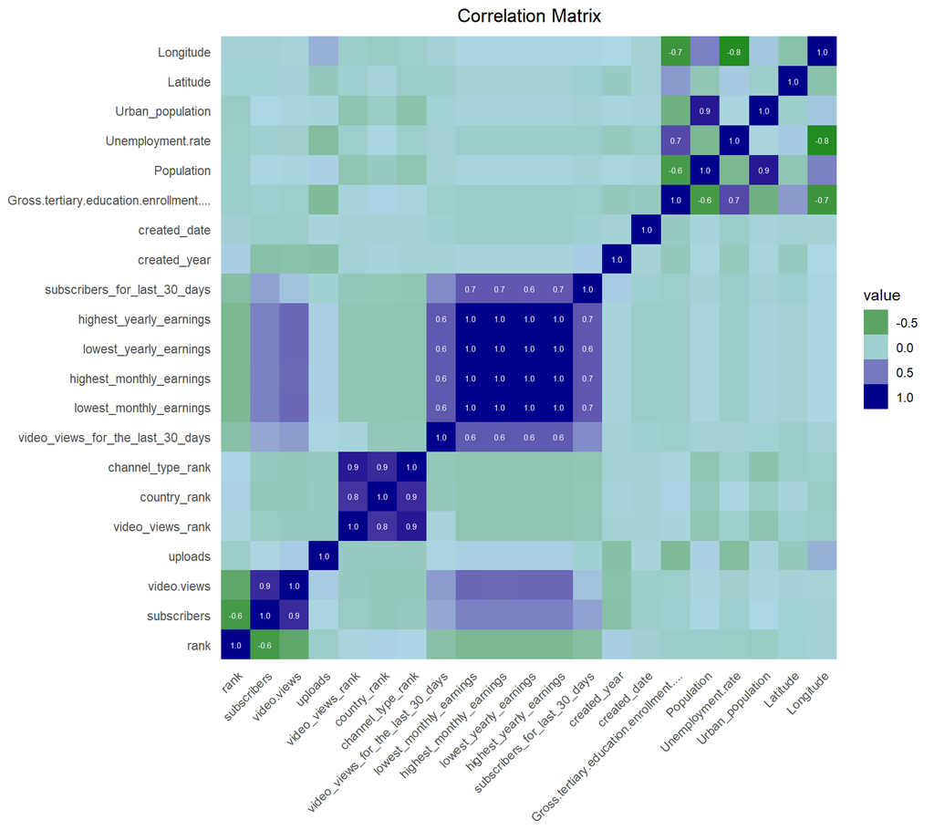

```r
plot_corr(youtube)
```

When investigating if some features can be dropped due to a linear relationship, it is common to plot a scatter matrix that plots each feature against each other feature. However, in this dataset which contains 28 features, that would require 28^2 (784) plots. This is an unrealistic number to plot, display and sort through.

Therefore, we can plot a correlation matrix. The correlation value between a pair of features measures the degree of the linear relationship that they have. If the two features have a high correlation score (approaching 1) it means that they are linear and measure the same variable. Having too many highly correlated variables may present problems in the following ways:

- **Over fitting**: The model may make splits based on a small number of highly correlated features. This may cause over fitting problems.
- **Redundancy**: Removing highly correlated features only gives a small drop in accuracy while providing a significant increase in performance. This is because highly correlated features provide very little additional benefits in classification while adding unecessary complexity.
- **Improved Model Performance**: In some cases, removing highly correlated features can actually improve the performance of the model. When features are highly correlated, they can lead to multicollinearity, which can make it difficult for the model to estimate the individual effects of each feature on the target variable.

Examining the plot above, we can observe the following:

- `Urban_population` is highly correlated with `Population`
- `video_views_rank`, `country_rank` and `channel_type_rank` are highly correlated
- `video.views` and `subscribers` are highly correlated
- `video_views_for_the_last_30_days`, `lowest_monthly_earnings`, `highest_monthly_earnings`, `lowest_yearly_earnings` and `highest_yearly_earnings`
- `subscribers_for_last_30_days`, `lowest_monthly_earnings`, `highest_monthly_earnings`, `lowest_yearly_earnings` and `highest_yearly_earnings`

We will drop `Urban_population`, `country_rank` and `channel_type_rank` from the data set. As they are highly correlated with other variables. However, we will leave dealing with `video_views_for_the_last_30_days` and `subscribers_for_last_30_days` as they are highly correlated with our target variable and need to be examined in greater detail.

```r
youtube <- subset(youtube, select=-c(`Urban_population`, `country_rank`, `channel_type_rank`))
```

## Data Cleaning

The following steps were discussed in project 1 in relation to the data cleaning and will be repeated here:

There are channels with 0 uploads or video views. We are not interested in these channels as the data is likely to be incorrect given their popularity. Therefore, all observations with video views or uploads equal to 0 will be replaced with NaN.

```r
youtube <- youtube %>%
  mutate(video.views = na_if(video.views, 0),
         uploads = na_if(uploads, 0))
```

YouTube was founded in 2005, therefore any observation with a channel creation year prior to 2005 are errors and will be replaced with NaN to be counted as missing values.

```r
youtube <- youtube %>%
  mutate(created_year = ifelse(created_year < 2005, NA, created_year))
```

Data points in which the missing data was indicated using `nan` instead of `NA` which is the proper value to represent missing data in R. We will convert all those values to `NaN` in order to have all missing values represented uniformly.

```r
youtube <- youtube %>%
  mutate_all(~ ifelse(. %in% c("nan"), NA, .))
```

The rows where `video.views` and `uploads` are missing are also missing most of the data regarding earnings and geographical data. Therefore, we consider these rows to be of low quality and they will be deleted from the data set.

```r
youtube <- youtube[!(is.na(youtube$video.views) | is.na(youtube$uploads)), ]
```

For categorical variables, any values with NA or NaN will be converted to `missing`.

```r
youtube <- youtube %>%
  mutate(category = ifelse(is.na(category), "missing", category),
         Country = ifelse(is.na(Country), "missing", Country),
         Abbreviation = ifelse(is.na(Abbreviation), "missing", Abbreviation),
         channel_type = ifelse(is.na(channel_type), "missing", channel_type),
         created_month = ifelse(is.na(created_month), "missing", created_month))
```

The following columns contain duplicate information and will be removed:

```r
youtube <- subset(youtube, select = -c(category, Abbreviation))
```

## Unique Observations

```r
unique_counts <- sapply(youtube, function(x) length(unique(x)))
unique_counts_df <- data.frame(Column_Name = names(unique_counts), Unique_Count = unique_counts)
print(unique_counts_df)
```

```r
youtube <- subset(youtube, select = -c(rank, Youtuber, Title))
```

## Histograms of numeric variables

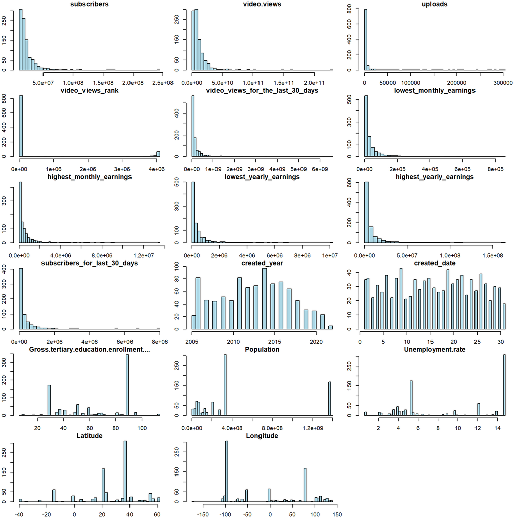

```r
plot_hist(youtube, 3, "default")
```

The function above shows the plot of histograms for the remaining numeric variables in the data set. It can be observed that many of the features, including `subscribers`, `video.views`, `uploads`, `video_views_rank`, `video_views_for_the_last_30_days`, `lowest_monthly_earnings`, `highest_monthly_earnings`, `lowest_yearly_earnings`, `highest_yearly earnings` and `subscribers_for_last_30_days` are right skewed. This means that the majority of the data points are concentrated on the left side of the distribution, with the tail extending to the right. In such cases, the mean is typically greater than the median, and extreme values can be substantially higher than the rest of the data points.

Having a right skew can impact model performance as many machine learning models assume that the features have a normal (Gaussian) distribution. When the features are skewed, it can lead to sub optimal performance as the models are less capable of capturing the underlying patterns in the skewed data.

We will investigate several transformations of these variables to determine which is the best option for our data. We will apply a log transform, min-max scaling and z-normalization to the following columns:

```r
cols_to_transform <- c(
  "subscribers", "video.views", "uploads", "video_views_rank",
  "video_views_for_the_last_30_days", "lowest_monthly_earnings",
  "highest_monthly_earnings", "lowest_yearly_earnings",
  "highest_yearly_earnings", "subscribers_for_last_30_days"
)
```

### Log transform

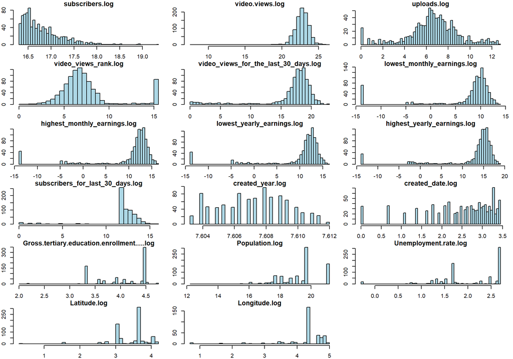

```r
youtube <- transform_cols(youtube, colnames(youtube)[sapply(youtube, is.numeric)],"log")

plot_hist(youtube, 3, "log")
```

A log transform is the most effect method for dealing with the right skewed data. Many statistical techniques and machine learning algorithms assume that data follows a normal (or Gaussian) distribution. Right-skewed data doesn’t meet this assumption. Applying a log transformation can help in making the data look more like a normal distribution. However, from our examinations of the data in the earlier parts of this document, we understand that many variables do have 0s in them and the logarithm of zero and negative numbers is undefined in the real number system. Therefore, the scaling function adds a small constant of `1e-6` to these values to avoid any infinite values in the transformed dataset.

### Min-Max scaling

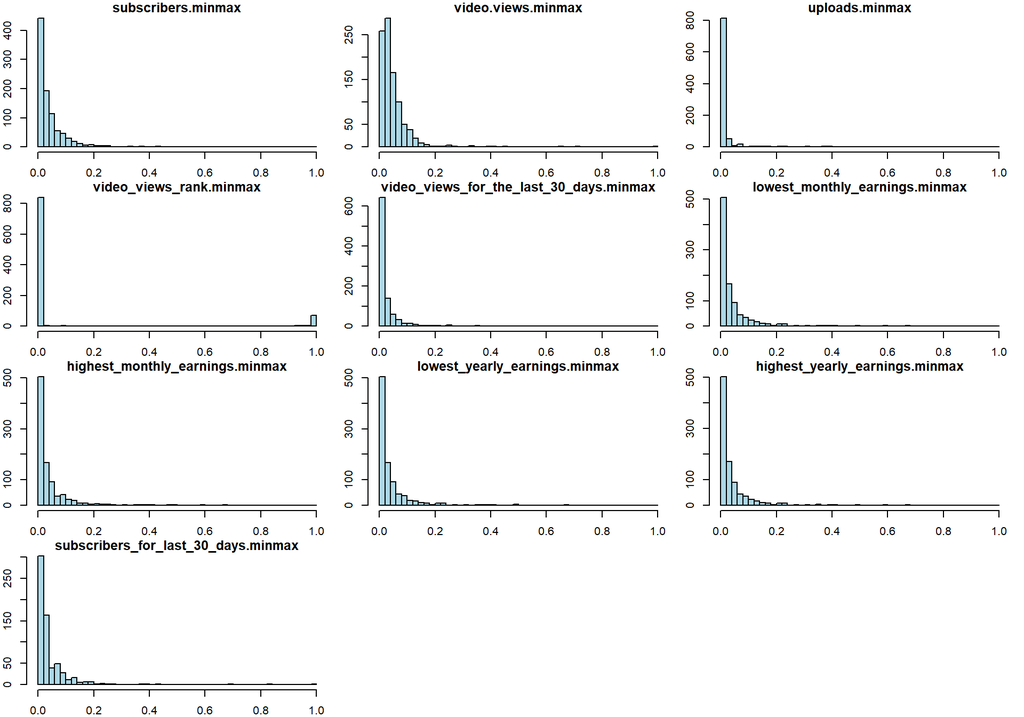

```r
youtube <- transform_cols(youtube, cols_to_transform,"minmax")
plot_hist(youtube, 3, "minmax")
```

The min-max scaler transforms the data to be within a given range which is very useful when dealing with data that has vastly different scales like the YouTube data set. In this case, the range chosen was [0,1]. However, just like z-normalization, min-max scaling is highly sensitive to outliers. Given the highly skewed distribution with a very long tail, min-max scaling will compress the majority of the scaled data into a small interval which is not helpful when trying to deal with a skewed distribution.

### Z-score normalization

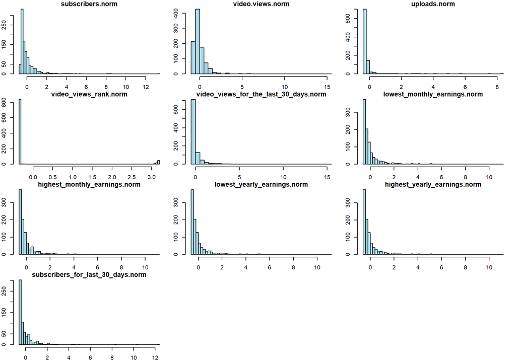

```r
youtube <- transform_cols(youtube, cols_to_transform,"norm")
plot_hist(youtube, 3, "norm")
```

Z-normalization involves scaling the features such that they have a mean of zero and a standard deviation of one. However, as shown in the plots above Z-normalization is not very useful for the YouTube data set. This is because Z-normalization is sensitive to outliers. Given that many of the features are heavily skewed with extreme values, the mean and standard deviation can be disproportionately affected. Standardizing in this context may not provide the intended scaling for the majority of the data points. Therefore, using Z-normalization does not address the issue of the skewed data that we are trying to rectify.

# Target Variable Selection

Given the nature of the YouTube data set, we will choose earnings as the target variable to determine the success or failure of a YouTube channel. To facilitate the classification, we will formulate it as a binary classification problem (high-earning/low-earning) as multiclass classification is very difficult.

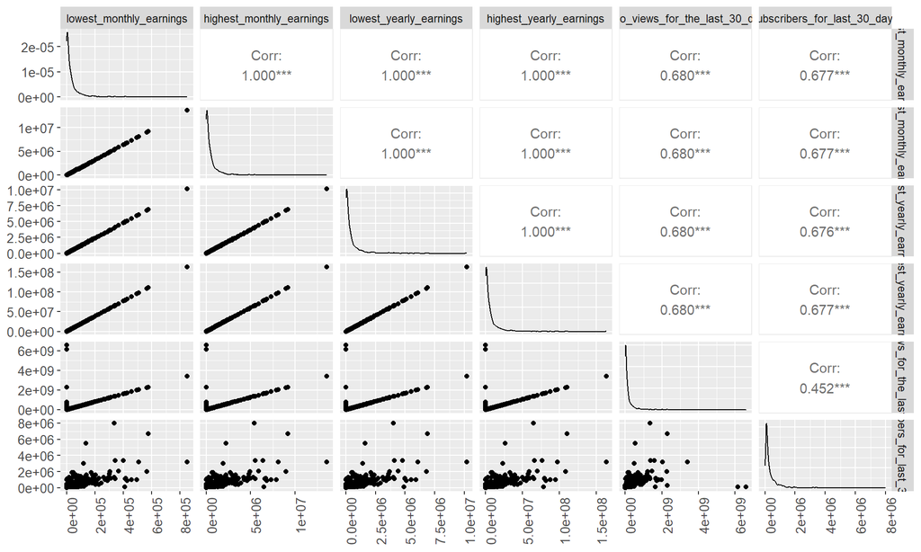

```r
earnings_subset <- youtube[, c("lowest_monthly_earnings",
  "highest_monthly_earnings", "lowest_yearly_earnings",
  "highest_yearly_earnings", "video_views_for_the_last_30_days", "subscribers_for_last_30_days")]

ggpairs(earnings_subset) +
  theme(axis.text.x = element_text(angle = 90, hjust = 1, size = 10),
        axis.text.y = element_text(size = 10))
```

We will take an average of the highest and lowest yearly earnings to form a new feature that we will use as our target variable. There are several reasons to use the average of the highest and lowest yearly earnings:

- Predicting the highest earnings may lead to over-optimistic predictions, influenced by extreme values or outliers. An average helps in reducing the influence of such extreme values.
- High earnings may have high variability, and focusing solely on them may lead to instability in predictions. Averaging helps in mitigating this variability.
- A model trained to predict average earnings tends to be more robust, as it learns the broader patterns in the data.

Once this target variable is created, we will remove the original 6 highly correlated variables to prevent them from affecting the training of the model.

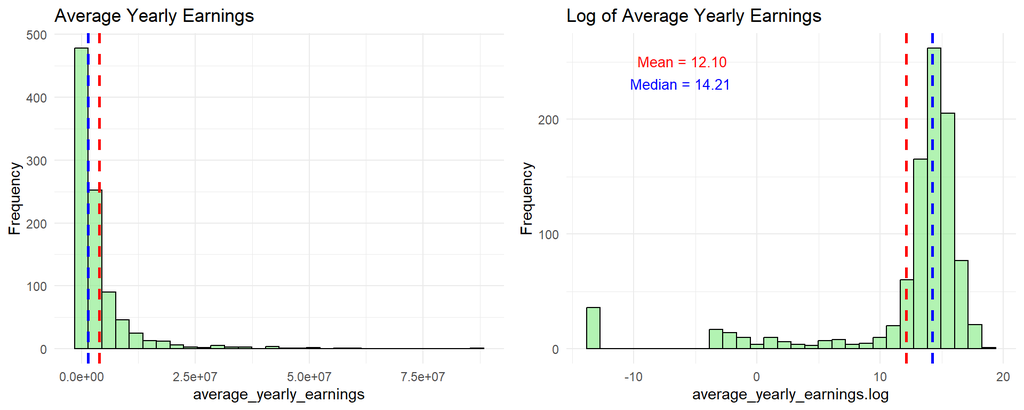

```r
youtube <- youtube %>%
  mutate(average_yearly_earnings = (lowest_yearly_earnings + highest_yearly_earnings) / 2)

youtube <- transform_cols(youtube, "average_yearly_earnings", "log")

p1 <- plot_individual_hist(youtube, "average_yearly_earnings", "Average Yearly Earnings", TRUE)
p2 <- plot_individual_hist(youtube, "average_yearly_earnings.log", "Log of Average Yearly Earnings", TRUE)

grid.arrange(p1,p2, ncol=2)
```

The histogram on the left shows the average yearly earnings target variable that was just created. Like many of the other features in this data set, it is right skewed. Therefore, we will perform a log transform on it to help normalize the distribution of the target variable.

As the earnings is presented as a continuous variable, we will need to find a threshold to determine what is considered high and low earning in order to formulate this as a binary classification problem. We will examine using the mean and median as the initial threshold.

```r
youtube$average_yearly_earnings.binary <- ifelse(youtube$average_yearly_earnings.log > 12.15, 1, 0)
table(youtube$average_yearly_earnings.binary)
```

```
##
##   0   1
## 178 771
```

```r
youtube$average_yearly_earnings.binary <- ifelse(youtube$average_yearly_earnings.log > 14.14, 1, 0)
table(youtube$average_yearly_earnings.binary)
```

```
##
##   0   1
## 462 487
```

The code above shows the number of each class in the newly created binary target variable when using the mean and median as the splitting threshold respectively. We can see that using the median produces a much better balance between the positive and negative classes this is important as the balance between positive and negative classes in the target variable can significantly impact the performance and interpretation of a machine learning model. When there’s a strong class imbalance, the majority class can dominate the minority class, leading to poor predictive performance for the minority class. A model may achieve high overall accuracy simply by predicting the majority class all the time, but it’s likely that the recall or precision for the minority class will be very low.

Therefore, going forward we will use the median to split the target variable for the binary classification tasks in the remainder of this notebook.

```r
outcome <- "average_yearly_earnings.binary"
pos <- 1

# Remove highly correlated cols
youtube <- subset(youtube, select=-c(average_yearly_earnings.log, highest_yearly_earnings.log, lowest_yearly_earnings.log, highest_monthly_earnings.log, lowest_monthly_earnings.log, video_views_for_the_last_30_days.log, subscribers_for_last_30_days.log, video_views_rank.log))
```

# Splitting the data

We will use a 90/10 split for the data. Given that the data set is relatively small (1000 obvs), we allocate a larger proportion for training to ensure that the model has enough data to learn for. We will also not split the data into train, calibration and test, instead opting to just split the dataset into train and test. In practice, the validation set is used to provide an unbiased evaluation of a model fit on the training data and to tune hyperparameters. However, we can achieve a similar result with k-fold cross validation and have more data to use for training and testing.

```r
# This function splits a dataframe into training and test sets given a particular ratio
# @param df the dataframe to operate on
# @param feature the feature to use as the vector of outcomes
# @param train_ratio the split to use
split_data <- function(df, feature, train_ratio = 0.9) {
  train_indices <- createDataPartition(df[,feature],  p= train_ratio, list = FALSE)

  # Split the data into training and test sets
  train_set <- df[train_indices, ]
  test_set <- df[-train_indices, ]

  # Return a list containing the training and test sets
  list(train = train_set, test = test_set)
}

# Retain only the log transformed variables
youtube_cleaned <- youtube[, grepl("\\.log$", names(youtube))]
youtube_cleaned <- bind_cols(youtube_cleaned, youtube[, c("average_yearly_earnings.binary", "Country", "channel_type", "created_month")])

splits <- split_data(youtube_cleaned, "average_yearly_earnings.binary", train_ratio = 0.9)
train_data <- splits$train
test_data <- splits$test
```

Split the data into categorical and numerical variables:

```r
# This function seperates a dataframe into categorical and numeric variables
# @param df the dataframe to operate on
separate_vars <- function(df) {
  numeric_var_names <- names(df)[sapply(df, is.numeric)]
  factor_var_names <- names(df)[sapply(df, is.character)]

  numVars <- subset(df, select=numeric_var_names)

  catVars <- subset(df, select=factor_var_names)

  return(list(numVars = numVars, catVars = catVars))
}

sep_train <- separate_vars(train_data)
numVars <- sep_train$numVars
catVars <- sep_train$catVars
```

# Single-Variable Models

The following function is used to process the categorical variables and perform single variable prediction for a given categorical column.

```r
mkPredC <- function(outCol, varCol, appCol) {
  pPos <- sum(outCol==pos)/length(outCol)
  naTab <- table(as.factor(outCol[is.na(varCol)]))
  pPosWna <- (naTab/sum(naTab))[pos]
  vTab <- table(as.factor(outCol), varCol)
  pPosWv <- (vTab[pos,]+1.0e-3*pPos)/(colSums(vTab)+1.0e-3)
  pred <- pPosWv[appCol]
  pred[is.na(appCol)] <- pPosWna
  pred[is.na(pred)] <- pPos
  pred
}

for (v in colnames(catVars)) {
  pi <- paste('pred', v, sep='')
  train_data[,pi] <- mkPredC(train_data[,outcome], train_data[,v], train_data[,v])
  test_data[,pi] <- mkPredC(test_data[,outcome], test_data[,v], test_data[,v])
}
```

The following function is used to process the numeric variables and perform single variable prediction for a given numeric column.

```r
# for numerical variables, we convert them into categorical one and
# call the `mkPredC` function above.
mkPredN <- function(outCol, varCol, appCol) {
  cuts <- unique(as.numeric(
    quantile(varCol, probs=seq(0, 1, 0.1), na.rm=T)))
  varC <- cut(varCol, cuts)
  appC <- cut(appCol, cuts)
  mkPredC(outCol, varC, appC)
}

# now go through all the numerical variables in the `numericVars` vector
# and perform the predictions. Again, the outputs are stored back into
# the data frame.
for (v in colnames(numVars)) {
  pi <- paste('pred', v, sep='')
  train_data[,pi] <- mkPredN(train_data[,outcome], train_data[,v], train_data[,v])
  test_data[,pi] <- mkPredN(test_data[,outcome], test_data[,v], test_data[,v])
}
```

## Evaulating Single Variable Models using AUC

The AUC, or Area Under the Receiver Operating Characteristic (ROC) Curve, is a commonly used metric in binary classification to evaluate the performance of a classifier. The AUC value ranges between 0 and 1, and a completely random classifier (a model with no discriminative power) is expected to have an AUC of 0.5.

```r
calcAUC <- function(predcol, outcol) {
  perf <- performance(prediction(predcol, outcol==pos),'auc')
  as.numeric(perf@y.values)
}
```

```r
for(v in colnames(catVars)) {
  pii <- paste('pred',v,sep='')
  aucTrain <- calcAUC(train_data[,pii],train_data[,outcome])

  print(sprintf(
    "%s, trainAUC: %4.3f",
    pii, aucTrain))

}
```

```
## [1] "predCountry, trainAUC: 0.331"
## [1] "predchannel_type, trainAUC: 0.350"
## [1] "predcreated_month, trainAUC: 0.446"
```

```r
for(v in colnames(numVars)) {
  pii<-paste('pred',v,sep='')
  aucTrain <- calcAUC(train_data[,pii],train_data[,outcome])

  if(aucTrain>=0.3) {
    print(sprintf(
      "%s, trainAUC: %4.3f",
      pii,aucTrain))
  }
}
```

```
## [1] "predsubscribers.log, trainAUC: 0.338"
## [1] "preduploads.log, trainAUC: 0.327"
## [1] "predcreated_year.log, trainAUC: 0.430"
## [1] "predcreated_date.log, trainAUC: 0.455"
## [1] "predGross.tertiary.education.enrollment.....log, trainAUC: 0.390"
## [1] "predPopulation.log, trainAUC: 0.399"
## [1] "predUnemployment.rate.log, trainAUC: 0.409"
## [1] "predLatitude.log, trainAUC: 0.384"
## [1] "predLongitude.log, trainAUC: 0.447"
```

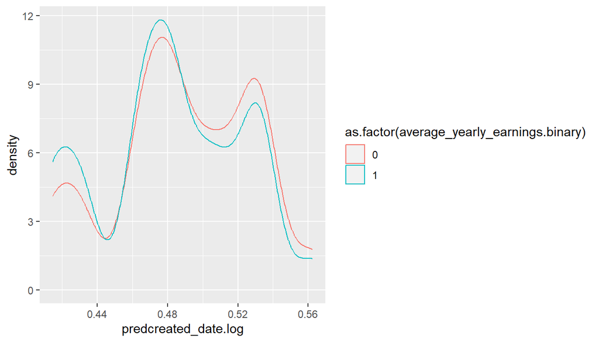

```r
ggplot(data=train_data) +
  geom_density(aes(x=predcreated_date.log,color=as.factor(average_yearly_earnings.binary)))
```

The single variable models do not perform well. Each and every variable has and AUC under 0.5. This signifies that using these variables as predictors performs worse than random guessing. In practical terms, if we were to reverse the predictions of such a classifier (i.e., predict class 0 as class 1), it would perform better than its current configuration.

The double density plot above illustrates the distributions of predicted probabilities for the `predcreated_date.log` feature which reported the highest AUC score in the previous test. We can see that the distributions overlap for the entire plot. Given this significant overlap across the entire range of data, we can see that the classifier has no idea what to predict which explains what it performs worse than the random classifier.

## Evaulating Single Variable Models using Log likelihood

```r
logLikelihood <- function(ypred, ytrue) {
  sum(ifelse(ytrue, log(ypred), log(1-ypred)), na.rm=T)
}
```

Compute the log likelihood of the Null model

```r
# Compute the likelihood of the Null model on the train set
logNull <- logLikelihood(sum(train_data[,outcome]==pos)/nrow(train_data), train_data[,outcome]==pos)

cat("The log likelihood of the Null model is:", logNull)
```

```
## The log likelihood of the Null model is: -592.2753
```

Next we run through categorical variables to select top performers:

```r
# selCatVars is a vector that keeps the names of the top performing categorical variables.
selCatVars <- c()
minDrop <- 0  # may need to adjust this number

for (v in colnames(catVars)) {
  pi <- paste('pred', v, sep='')
  devDrop <- 2*(logLikelihood(train_data[,pi], train_data[,outcome]==pos) - logNull)
  if (devDrop >= minDrop) {
    cat(sprintf("%6s, deviance reduction: %g\n", v, devDrop))
    selCatVars <- c(selCatVars, pi)
  }
}
selCatVars
```

Run through numerical variables to select top performers

```r
selNumVars <- c()
minDrop <- -10  # may need to adjust this number
for (v in colnames(numVars)) {
  pi <- paste('pred', v, sep='')
  devDrop <- 2*(logLikelihood(train_data[,pi], train_data[,outcome]==pos) - logNull)
  print(devDrop)
  if (devDrop >= minDrop) {
    cat(sprintf("%6s, deviance reduction: %g\n", v, devDrop))
    selNumVars <- c(selNumVars, pi)
  }
}
```

```
## [1] -231.7365
## [1] -Inf
## [1] -Inf
## [1] -Inf
## [1] -19.28421
## [1] -117.1748
## [1] -120.5228
## [1] -122.9904
## [1] -127.8959
## [1] -43.43864
## [1] -Inf
```

```r
selNumVars
```

# Feature Selection

## Forward Selection

Forward selection is a stepwise method used in the context of regression modeling and other predictive modeling techniques. Its main aim is to select a subset of predictors (also known as features or variables) that contribute the most to the prediction of the dependent variable, while discarding predictors that do not add significant predictive power. The process is used to combat overfitting, simplify models, and possibly improve prediction performance.

In this project, we perform forward selection using Akaike Information Criterion (AIC). AIC balances two essential aspects of modeling, the goodness-of-fit and the number of parameters used. Models that fit the data very well but are overly complex (use many parameters) are penalized.

AIC is formulated as:

AIC = 2k - 2ln(L)

Where:

- k is the number of parameters in the model.
- L is the likelihood of the model.

The objective in using AIC for model selection is to find the model that has the lowest AIC value. Lower AIC values suggest better model fit when penalizing for the number of predictors, ensuring that we don’t overfit with too many variables.

```r
# This function performs feature selection using forward selection
# @param df The dataframe that contains the features
# @param response The response variable
forward_selection <- function(df, response) {
  # Get names of variables minus response variable
  predictors <- setdiff(names(df), response)
  # What features we select
  included <- c()
  best_aic <- Inf

  # Loop to iteratively add predictors
  while(length(predictors) > 0) {
    aics <- rep(Inf, length(predictors))

    # Test each predictor
    for(j in seq_along(predictors)) {
      formula <- paste(response, "~", paste(c(included, predictors[j]), collapse = "+"))
      model <- lm(formula, data = df)
      aics[j] <- AIC(model)
    }

    # If we find a predictor that reduces the AIC, we include it
    if(min(aics) < best_aic) {
      best_aic <- min(aics)
      include <- predictors[which.min(aics)]
      included <- c(included, include)
      predictors <- setdiff(predictors, include)
    } else {
      break
    }
  }

  return(included)
}
```

```r
selected_features <- forward_selection(train_data, "average_yearly_earnings.binary")

train_forward_sel <- subset(train_data, select=c(selected_features))
test_forward_sel <- subset(test_data, select=c(selected_features))

train_forward_sel$average_yearly_earnings.binary <- as.factor(train_data$average_yearly_earnings.binary)
test_forward_sel$average_yearly_earnings.binary <- as.factor(test_data$average_yearly_earnings.binary)

print(selected_features)
```

```
## [1] "video.views.log" "Country"         "uploads.log"     "channel_type"
## [5] "created_month"
```

## Fisher’s Score

Fisher’s score, is a method used in feature selection. It assesses the discriminating power of individual features with respect to different classes. It’s especially effective for datasets with continuous features and categorical class labels.

The fundamental idea behind Fisher’s score is to rank features based on their ability to differentiate between classes. This ability is gauged by considering the ratio of between-class variance to within-class variance.

The function below ranks the features based on their Fisher’s Score.

```r
fisher_score <- function(train_data, target_column) {

  # Extract unique class labels
  classes <- unique(train_data[[target_column]])

  if(length(classes) != 2) {
    stop("The provided data does not have two classes. Fisher's Score here is designed for binary classification.")
  }

  # Split the data based on classes
  class1_data <- train_data[train_data[[target_column]] == classes[1], ]
  class2_data <- train_data[train_data[[target_column]] == classes[2], ]

  # Compute means for each class without target column
  class1_means <- colMeans(class1_data[, !(names(class1_data) %in% target_column)])
  class2_means <- colMeans(class2_data[, !(names(class2_data) %in% target_column)])

  # Compute variance for each class without target column
  class1_variances <- apply(class1_data[, !(names(class1_data) %in% target_column)], 2, var)
  class2_variances <- apply(class2_data[, !(names(class2_data) %in% target_column)], 2, var)

  # Compute Fisher's Score for each feature
  between_class_variance <- (class1_means - class2_means)^2
  within_class_variance <- class1_variances + class2_variances

  fisher_scores <- between_class_variance / within_class_variance

  # Sort features by Fisher's Score in descending order and get their names
  ranked_feature_names <- names(sort(fisher_scores, decreasing = TRUE))

  return(ranked_feature_names)
}
```

```r
fisher_features <- fisher_score(train_data, "average_yearly_earnings.binary")
k <- 7
top_fisher_features <- fisher_features[1:k]

train_fisher <- subset(train_data, select=c(top_fisher_features))
test_fisher <- subset(test_data, select=c(top_fisher_features))

train_fisher$average_yearly_earnings.binary <- as.factor(train_data$average_yearly_earnings.binary)
test_fisher$average_yearly_earnings.binary <- as.factor(test_data$average_yearly_earnings.binary)


print(top_fisher_features)
```

```
## [1] "video.views.log"
## [2] "Country"
## [3] "uploads.log"
## [4] "channel_type"
## [5] "subscribers.log"
## [6] "Population.log"
## [7] "Gross.tertiary.education.enrollment.....log"
```

## Principal Component Analysis (PCA)

Many machine learning problems face the problem of having too many features which makes the training process very slow and also can possibly make it hard to converge on an optimal solution, which is referred to as the **curse of dimensionality**. One of the approaches that can be used to solve this is through dimensionality reduction techniques. This not only speeds up training, it also makes it significantly easier to visualize the data, reducing a training set to 2 or 3 dimensions can make it possible to plot a condensed view of a high dimensional training set and gain insights on potential clusters in the data.

Principal Component Analysis (PCA) is one such dimensionality reduction technique. PCA identifies the hyper plane that preserves the maximum variance of the data and then projects the data onto it. The first principal component is the axis that accounts for the largest amount of the variance in the training set, and the second principal component is orthogonal to the first one, that accounts for the largest amount of the remaining variance.

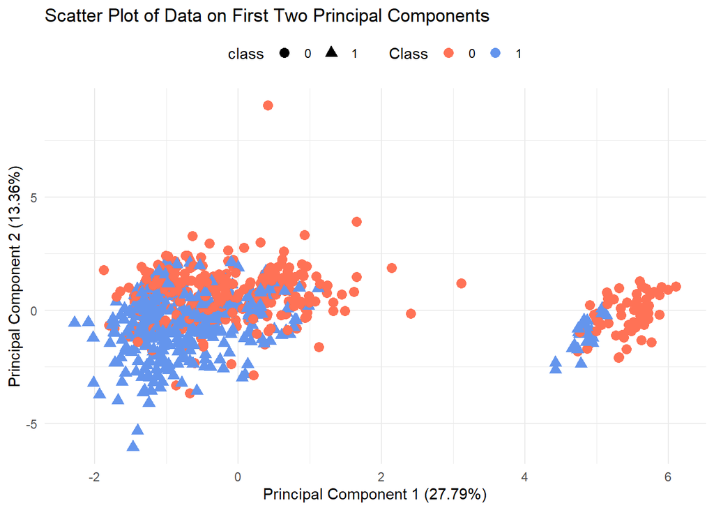

```r
# Perform PCA
pca <- prcomp(subset(train_data, select=-c(average_yearly_earnings.binary)), center = TRUE, scale. = TRUE, rank. = 2)

# Get the explained variance ratio
explained_variance_ratio <- pca$sdev^2 / sum(pca$sdev^2)

# Convert principal components and cn_train_y into a data frame for ggplot
df_pca <- as.data.frame(pca$x)
df_pca$class <- as.factor(train_data$average_yearly_earnings.binary)

# Create a scatter plot with different colors for the two classes using ggplot2
ggplot(df_pca, aes(x = PC1, y = PC2, color = class)) +
  geom_point(aes(shape = class), size = 3) +
  scale_color_manual(values = c("coral1", "cornflowerblue"), name = "Class") +
  labs(x = sprintf('Principal Component 1 (%.2f%%)', explained_variance_ratio[1]*100),
       y = sprintf('Principal Component 2 (%.2f%%)', explained_variance_ratio[2]*100),
       title = 'Scatter Plot of Data on First Two Principal Components') +
  theme_minimal() +
  theme(legend.position = "top")
```

The plot above shows the scatter plot of the data on the first two principal components. We can observe the following:

The explained variance ratio provides insight into the relative importance or contribution of each principal component in capturing the underlying structure of the data. Higher values indicate that the corresponding principal component retains more information about the original dataset.

The first principal component captures a significant portion of the variance, indicating that it carries valuable information and potentially separates the classes to a certain extent. The second principal component also contributes to the overall variance, but to a lesser extent compared to the first component.

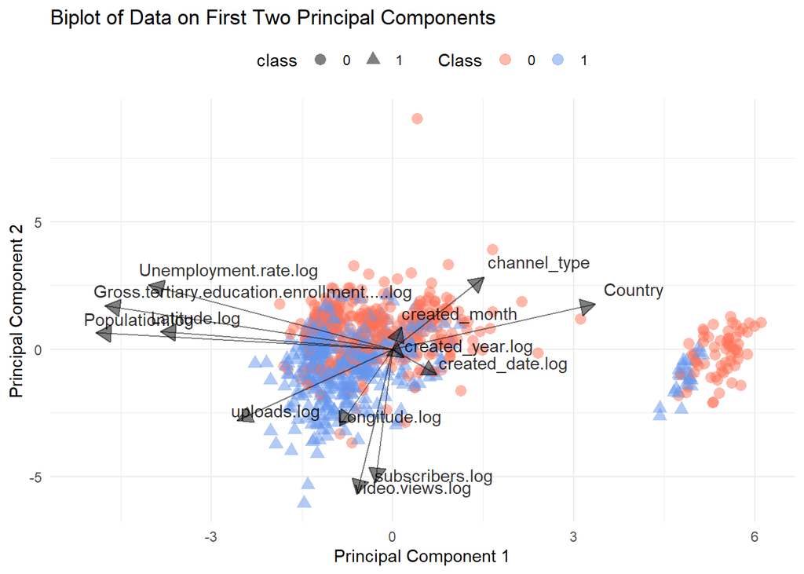

```r
df_pca <- as.data.frame(pca$x)
df_pca$class <- as.factor(train_data$average_yearly_earnings.binary)

variable_vectors <- pca$rotation[, 1:2]

p <- ggplot(df_pca, aes(x = PC1, y = PC2, color = class)) +
  geom_point(aes(shape = class), size = 3, alpha = 0.5) +   # Semi-transparent points
  scale_color_manual(values = c("coral1", "cornflowerblue"), name = "Class") +
  theme_minimal() +
  theme(legend.position = "top") +
  labs(x = 'Principal Component 1',
       y = 'Principal Component 2',
       title = 'Biplot of Data on First Two Principal Components')

variable_vectors_df <- as.data.frame(variable_vectors)
variable_vectors_df$label <- rownames(variable_vectors)

multiplier <- 2

p <- p +
     geom_segment(data = variable_vectors_df,
                  aes(x = 0, y = 0,
                      xend = PC1 * 5 * multiplier, yend = PC2 * 5 * multiplier),
                  arrow = arrow(type = "closed", length = unit(0.15, "inches")),
                  color = 'black', alpha = 0.5) +
     geom_text(data = variable_vectors_df,
               aes(x = PC1 * 5.2 * multiplier, y = PC2 * 5.2 * multiplier, label = label),
               vjust = -0.5, hjust = 0, alpha = 0.8, inherit.aes = FALSE)

# Display the plot
print(p)
```

The plot above shows the biplot of the data on the first two principal components. The horizontal axis represents the first principal component (PC1), which captures the most significant variation in the data. The vertical axis represents the second principal component (PC2), which captures the second most significant variation orthogonal to PC1.

- The features are represented as arrows in the plot
- The direction and length of the arrows indicate the contribution of each variable to the principal components.
- Variables pointing in the same direction are positively correlated, while those pointing in opposite directions are negatively correlated.
- Longer arrows represent variables with a stronger influence on the principal components.

### Using PCA to retain 95% of the explained variance

[figure not shown]

```r
# Compute the PCA without limiting to 2 PC
pca <- prcomp(train_data, center = TRUE, scale. = TRUE)
explained_variance_ratio <- pca$sdev^2 / sum(pca$sdev^2)
cumulative_variance <- cumsum(explained_variance_ratio)
num_components <- which(cumulative_variance >= 0.95)[1]

explained_variance_data <- data.frame(
  Dimension = 1:length(explained_variance_ratio),
  ExplainedVariance = explained_variance_ratio,
  CumulativeVariance = cumulative_variance
)


ggplot(explained_variance_data, aes(x = Dimension)) +
  geom_bar(aes(y = ExplainedVariance), stat = "identity", fill = "blue", alpha = 0.7) +
  geom_line(aes(y = CumulativeVariance), color = "red", size = 1.2) +
  geom_point(aes(y = CumulativeVariance), color = "red") +
  geom_vline(aes(xintercept = 10), color = "black", linetype = "dashed", size = 1) +
  annotate("text", x = num_components, y = 0.8, label = "Number of components required\nto retain 95% of the\nexplained variance", hjust = 0.25) +
  labs(
    title = "Explained Variance as a Function of Dimensions",
    x = "Number of Dimensions",
    y = "Variance Explained",
    caption = "Blue Bars = Individual Explained Variance\nRed Line = Cumulative Explained Variance"
  ) +
  scale_y_continuous(labels = scales::percent) +
  theme_minimal()
```

```r
# Function to apply PCA transformation on new datasets
transform_data <- function(data, pca, num_components) {
  centered_data <- scale(data, center = pca$center, scale = pca$scale)
  pc_scores <- centered_data %*% pca$rotation[, 1:num_components]
  return(as.data.frame(pc_scores))
}


train_pca <- as.data.frame(pca$x[, 1:num_components])
test_pca <- transform_data(test_data, pca, num_components)

train_pca$average_yearly_earnings.binary <- as.factor(train_data$average_yearly_earnings.binary)
test_pca$average_yearly_earnings.binary <- as.factor(test_data$average_yearly_earnings.binary)
```

# Evaluation of Models

## Functions

We will evaluate the Decision Tree and Logistic Regression Models using the 4 functions shown below:

This function calculates the Accuracy, Precision, Recall and F1 score of a given model.

- **Accuracy**: Measures the fraction of correct predictions made by the model out of all predictions.
  - Accuracy = Number of correct predictions / total number of all predictions
- **Precision**: Measures the fraction of relevant instances among the retrieved instances.Out of all the positive predictions made by the model, how many were actually positive.
  - Precision = True Positive (TP) / (True Positive + False Positive)
  - Precision is especially important when the cost of a false positive is high.
- **Recall**: Measures the fraction of relevant instances that have been retrieved over the total amount of relevant instances. Out of all the actual positives, how many were predicted as positive by the model.
  - Recall = True Positive (TP) / (True Positive + False Negatives)
  - Recall is crucial when the cost of a false negative is high.
- **F1 Score**: Harmonic mean of precision and recall. The F1 score demonstrates the precision/recall trade off. The F1 score cannot be high unless both precision and recall are high.
  - The F1 score ranges between 0 (worst) and 1 (best). An F1 score of 1 indicates perfect precision and recall, while a score of 0 indicates that either the precision or the recall is zero.

```r
# This function calculates the accuracy, precision, recall and F1 score for a model
cal_scores <- function(train_data, train_pred, calibration_data, calibration_pred){

  # Calculate metrics for the training data
  train_results <- tibble(
    Accuracy  = accuracy_vec(train_data$average_yearly_earnings.binary, train_pred$.pred_class),
    Precision = precision_vec(train_data$average_yearly_earnings.binary, train_pred$.pred_class),
    Recall    = recall_vec(train_data$average_yearly_earnings.binary, train_pred$.pred_class),
    F1        = f_meas_vec(train_data$average_yearly_earnings.binary, train_pred$.pred_class)
  )

  # Calculate metrics for the calibration data
  calibration_results <- tibble(
    Accuracy  = accuracy_vec(calibration_data$average_yearly_earnings.binary, calibration_pred$.pred_class),
    Precision = precision_vec(calibration_data$average_yearly_earnings.binary, calibration_pred$.pred_class),
    Recall    = recall_vec(calibration_data$average_yearly_earnings.binary, calibration_pred$.pred_class),
    F1        = f_meas_vec(calibration_data$average_yearly_earnings.binary, calibration_pred$.pred_class)
  )

  list(train = train_results, calibration = calibration_results)
}
```

This function visualizes the precision and recall as a function of the threshold. By plotting precision and recall against the threshold, one can visually inspect the trade-offs. At some thresholds, precision might be high but recall is low and vice versa. Understanding this trade-off can help in deciding the optimal threshold.

```r
# This function plots precision and recall vs threshold
plot_precision_recall_vs_threshold <- function(pred, data, title) {
  # Predict the probabilities
  probs <-pred$.pred_1

  # Create a data frame with true labels and predicted probabilities
  results <- data.frame(
    True = data$average_yearly_earnings.binary,
    Prob = probs
  )

  # For each threshold, compute precision and recall
  thresholds <- seq(0, 1, by = 0.01)
  metrics <- sapply(thresholds, function(thresh) {
    predictions <- ifelse(results$Prob > thresh, 1, 0)
    # Ensure predictions always have levels 0 and 1
    predictions <- factor(predictions, levels = c(0, 1))

    precision <- precision_vec(results$True, predictions)
    recall <- recall_vec(results$True, predictions)
    c(Precision = precision, Recall = recall)
  })

  # Transform results for plotting
  df <- as.data.frame(t(metrics))
  df$Threshold <- thresholds
  df$Difference <- abs(df$Precision - df$Recall)
  intersection_point <- df[which.min(df$Difference), "Threshold"]

  p <- ggplot(df, aes(x = Threshold)) +
    geom_line(aes(y = Precision, color = 'Precision')) +
    geom_line(aes(y = Recall, color = 'Recall')) +
    labs(title = title,
         y = "Value",
         x = "Threshold",
         color = "Metric") +
    geom_vline(aes(xintercept = 0.5), linetype = "dashed", color = "black", size = 0.5) +
    geom_text(aes(x = 0.5, y = 0.2, label = "Default threshold"), angle = 90, vjust = -0.5) +
    geom_vline(aes(xintercept = intersection_point), linetype = "dashed", color = "red", size = 0.5) +
    geom_text(aes(x = intersection_point, y = 0.2,
                  label = paste0("Intersection ", round(intersection_point, 2))), angle = 90, vjust = -0.5) +
    theme_minimal()

  return(p)
}
```

This function plots the Receiver Operating Characteristic (ROC) and displays the Area Under Curve (AUC). The Receiver Operating Characteristic (ROC) is a graphical representation used to evaluate the performance of binary classification models. It illustrates the diagnostic ability of a classifier system as its discrimination threshold changes. The ROC curve plots the True Positive Rate (TPR) against the False Positive Rate (FPR) for various threshold values.

AUC is a metric that quantifies the overall ability of the classifier to distinguish between positive and negative classes. An AUC of 1 indicates a perfect classifier, while an AUC of 0.5 indicates no discrimination capability. AUC values between 0 and 0.5 suggest a model that performs worse than random guessing.

```r
# This function plots the ROC
plot_roc <- function(predictions, data, title) {
  # Predict the probabilities
  probs <- predictions$.pred_1
  pred <- prediction(probs, data$average_yearly_earnings.binary)
  perf <- performance(pred, "tpr", "fpr")
  roc_data <- data.frame(
    FPR = unlist(perf@x.values),
    TPR = unlist(perf@y.values)
  )
  auc <- performance(pred, measure = "auc")
  auc_value <- unlist(auc@y.values)
  ggplot(roc_data, aes(x = FPR, y = TPR)) +
    geom_line(color = "blue") +
    geom_abline(intercept = 0, slope = 1, linetype = "dashed") +
    geom_text(aes(x = 0.5, y = 0.25),
              label = paste("AUC =", round(auc_value, 2)),
              color = "red") +
    labs(title = title,
         x = "False Positive Rate",
         y = "True Positive Rate") +
    coord_fixed(ratio = 1) +
    theme_minimal()
}
```

This function plots the confusion matrix. The confusion matrix, is a table used to evaluate the performance of a classification model. It provides a breakdown of predictions into a table showing correct predictions and the types of incorrect predictions made. It is particularly useful for a more detailed analysis of where a classification model is getting things right and where it’s making errors.

```r
# Plot confusion matrix
plot_con_matrix <- function(pred, data, title){
  cm <- confusionMatrix(as.factor(pred[[1]]), data$average_yearly_earnings.binary)
  plt <- as.data.frame(cm$table)
  plt$Prediction <- factor(plt$Prediction, levels=rev(levels(plt$Prediction)))
  ggplot(plt, aes(Prediction,Reference, fill= Freq)) +
          geom_tile() + geom_text(aes(label=Freq)) +
          scale_fill_gradient(low="white", high="#009194") +
          labs(title = title, x = "Reference",y = "Prediction")
}
```

# Logistic Regression Classifier

The first classification method used will be logistic regression. Logistic Regression is a statistical method used for modeling the probability of a certain class (high/low earnings). It’s especially used in cases where the response variable is categorical, most commonly binary. We have binarized our target variable in an earlier part of this report to make it compatible with the logistic regression classifier.

As mentioned earlier in the report when we were splitting the data into training and testing sets, we did not make use of a calibration set as we were going to use k-fold cross-validation to pick the best model. K-fold cross validation is a widely used technique for assessing the performance of machine learning models. With a single train/test split, the evaluation can vary a lot based on which data points end up in the training set and which ones end up in the test set. K-fold cross validation, by averaging results from multiple partitions, reduces this variability and provides a more stable and robust estimate of model performance.

The function below allows us to train a logistic regression model given a dataset.

```r
# Train a logistic regression model using glm and 10 fold cross validation
train_log_reg <- function(df) {
  trControl <- trainControl(method = "cv", number = 10)
  model <- train(
    average_yearly_earnings.binary ~ .,
    data = df,
    method = "glm",
    family = "binomial",
    trControl = trControl
  )
  return(model)
}
```